# Human Activity Recognition - Weight Lifting Exercises (HAR - WLE)

Md. Moaz Ahmed Asif

2023-04-25

## Synopsis

Using devices such as Jawbone Up, Nike FuelBand, and Fitbit it is now possible to collect a large amount of data about personal activity relatively inexpensively. These type of devices are part of the quantified self movement – a group of enthusiasts who take measurements about themselves regularly to improve their health, to find patterns in their behavior, or because they are tech geeks. One thing that people regularly do is quantify how much of a particular activity they do, but they rarely quantify how well they do it. In this project, your goal will be to use data from accelerometers on the belt, forearm, arm, and dumbell of 6 participants. They were asked to perform barbell lifts correctly and incorrectly in 5 different ways. More information is available from the website [here](http://groupware.les.inf.puc-rio.br/har) (see the section on the Weight Lifting Exercise Dataset).

## Data Processing

The training data for this project are available [here](https://d396qusza40orc.cloudfront.net/predmachlearn/pml-training.csv) & the test data are available [here](https://d396qusza40orc.cloudfront.net/predmachlearn/pml-testing.csv) and read by the read.csv() function. The data for this project come from [here](http://groupware.les.inf.puc-rio.br/har).

```r
training_raw <- read.csv("./data/pml-training.csv", header = T); dim(training_raw)
```

```
## [1] 19622   160
```

```r
testing_raw <- read.csv("./data/pml-testing.csv", header = T); dim(testing_raw)
```

```
## [1]  20 160
```

```r
head(colnames(training_raw), 10)
```

```
##  [1] "X"                    "user_name"            "raw_timestamp_part_1"
##  [4] "raw_timestamp_part_2" "cvtd_timestamp"       "new_window"
##  [7] "num_window"           "roll_belt"            "pitch_belt"
## [10] "yaw_belt"
```

The first 7 columns are ID and time variables. So, we do not need them for analysis.

```r
training_raw <- training_raw[, -c(1:7)]; dim(training_raw)
```

```
## [1] 19622   153
```

```r
testing_raw <- testing_raw[, -c(1:7)]; dim(testing_raw)
```

```
## [1]  20 153
```

Up next, the libraries needed for analysis are loaded.

```r
library(caret)
library(kernlab)
library(rpart)
library(ggplot2)
library(randomForest)
library(rattle)
library(Metrics)
```

Next, near zero variance variables are removed from the training data set and also from the testing data set.

```r
NZV_train <- nearZeroVar(training_raw)
training_raw <- training_raw[, -NZV_train]; dim(training_raw)
```

```
## [1] 19622    94
```

```r
NZV_test <- nearZeroVar(testing_raw)
testing_raw <- testing_raw[, -NZV_test]; dim(testing_raw)
```

```
## [1] 20 53
```

At last, NA values are removed.

```r
training_raw <- training_raw[, colSums(is.na(training_raw)) == 0]; dim(training_raw)
```

```
## [1] 19622    53
```

```r
testing_raw <- testing_raw[, colSums(is.na(testing_raw)) == 0]; dim(testing_raw)
```

```
## [1] 20 53
```

## Data Analysis

For cross-validation, a sub-training data set and a validation data set are created by splitting the training data into a 70:30 ratio.

```r
set.seed(123321)
inTrain <- createDataPartition(training_raw$classe, p = 0.7, list = F)
training_Data <- training_raw[inTrain, ]; dim(training_Data)
```

```
## [1] 13737    53
```

```r
validation_Data <- training_raw[-inTrain, ]; dim(validation_Data)
```

```
## [1] 5885   53
```

## Creating and Testing the Models

Decision Tree, Random Forrest, Gradient Boosted Machine (GBM), Support Vector Machine (SVM), and Linear Discriminant Analysis (LDA) models were created and tested. Now, let’s set up a control for the sub-training data set to use cross-validation.

```r
control <- trainControl(method = "repeatedcv", number = 3, repeats = 5, verboseIter = F)
```

### Decision Tree Model

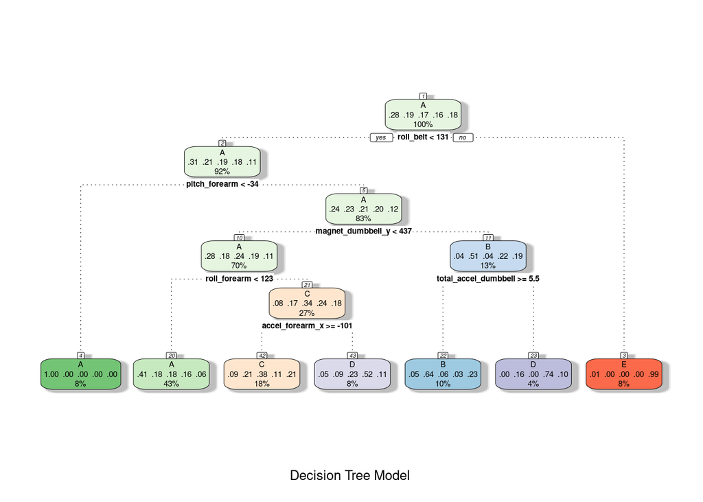

```r
dec_tree_model <- train(classe ~., data = training_Data, method = "rpart", trControl = control, tuneLength = 5)
fancyRpartPlot(dec_tree_model$finalModel, sub = "Decision Tree Model")
```

```r
pred_dec_tree <- predict(dec_tree_model, validation_Data)
confusionMatrix(pred_dec_tree, reference = factor(validation_Data$classe))
```

```
## Confusion Matrix and Statistics
##
##           Reference
## Prediction    A    B    C    D    E
##          A 1517  456  501  451  139
##          B   30  354   35    7  119
##          C   92  246  388  119  263
##          D   29   83  102  387   72
##          E    6    0    0    0  489
##
## Overall Statistics
##
##                Accuracy : 0.5327
##                  95% CI : (0.5199, 0.5455)
##     No Information Rate : 0.2845
##     P-Value [Acc > NIR] : < 2.2e-16
##
##                   Kappa : 0.3907
##
##  Mcnemar's Test P-Value : < 2.2e-16
##
## Statistics by Class:
##
##                      Class: A Class: B Class: C Class: D Class: E
## Sensitivity            0.9062  0.31080  0.37817  0.40145  0.45194
## Specificity            0.6326  0.95976  0.85182  0.94188  0.99875
## Pos Pred Value         0.4951  0.64954  0.35018  0.57504  0.98788
## Neg Pred Value         0.9443  0.85300  0.86644  0.88929  0.88998
## Prevalence             0.2845  0.19354  0.17434  0.16381  0.18386
## Detection Rate         0.2578  0.06015  0.06593  0.06576  0.08309
## Detection Prevalence   0.5206  0.09261  0.18828  0.11436  0.08411
## Balanced Accuracy      0.7694  0.63528  0.61499  0.67167  0.72535
```

So, the out of sample error for this model will be:

```r
1-as.numeric(confusionMatrix(pred_dec_tree, reference = factor(validation_Data$classe))$overall["Accuracy"])
```

```
## [1] 0.4672897
```

### Random Forrest Model

```r
rf_model <- train(classe ~., data = training_Data, method = "rf", trControl = control, tuneLength = 5)
pred_rf <- predict(rf_model, validation_Data)
confusionMatrix(pred_rf, reference = factor(validation_Data$classe))
```

```
## Confusion Matrix and Statistics
##
##           Reference
## Prediction    A    B    C    D    E
##          A 1670    5    0    0    0
##          B    3 1127    3    0    0
##          C    0    7 1020    8    3
##          D    0    0    3  955    5
##          E    1    0    0    1 1074
##
## Overall Statistics
##
##                Accuracy : 0.9934
##                  95% CI : (0.991, 0.9953)
##     No Information Rate : 0.2845
##     P-Value [Acc > NIR] : < 2.2e-16
##
##                   Kappa : 0.9916
##
##  Mcnemar's Test P-Value : NA
##
## Statistics by Class:
##
##                      Class: A Class: B Class: C Class: D Class: E
## Sensitivity            0.9976   0.9895   0.9942   0.9907   0.9926
## Specificity            0.9988   0.9987   0.9963   0.9984   0.9996
## Pos Pred Value         0.9970   0.9947   0.9827   0.9917   0.9981
## Neg Pred Value         0.9990   0.9975   0.9988   0.9982   0.9983
## Prevalence             0.2845   0.1935   0.1743   0.1638   0.1839
## Detection Rate         0.2838   0.1915   0.1733   0.1623   0.1825
## Detection Prevalence   0.2846   0.1925   0.1764   0.1636   0.1828
## Balanced Accuracy      0.9982   0.9941   0.9952   0.9945   0.9961
```

So, the out of sample error for this model will be:

```r
1-as.numeric(confusionMatrix(pred_rf, reference = factor(validation_Data$classe))$overall["Accuracy"])
```

```
## [1] 0.006627018
```

### Gradient Boosted Machine (GBM) Model

```r
gbm_model <- train(classe ~., data = training_Data, method = "gbm", trControl = control, tuneLength = 5)
```

```r
pred_gbm <- predict(gbm_model, validation_Data)
confusionMatrix(pred_gbm, reference = factor(validation_Data$classe))
```

```
## Confusion Matrix and Statistics
##
##           Reference
## Prediction    A    B    C    D    E
##          A 1662   10    0    0    0
##          B    8 1119    4    0    5
##          C    4   10 1018    7    3
##          D    0    0    4  957    8
##          E    0    0    0    0 1066
##
## Overall Statistics
##
##                Accuracy : 0.9893
##                  95% CI : (0.9863, 0.9918)
##     No Information Rate : 0.2845
##     P-Value [Acc > NIR] : < 2.2e-16
##
##                   Kappa : 0.9865
##
##  Mcnemar's Test P-Value : NA
##
## Statistics by Class:
##
##                      Class: A Class: B Class: C Class: D Class: E
## Sensitivity            0.9928   0.9824   0.9922   0.9927   0.9852
## Specificity            0.9976   0.9964   0.9951   0.9976   1.0000
## Pos Pred Value         0.9940   0.9850   0.9770   0.9876   1.0000
## Neg Pred Value         0.9972   0.9958   0.9983   0.9986   0.9967
## Prevalence             0.2845   0.1935   0.1743   0.1638   0.1839
## Detection Rate         0.2824   0.1901   0.1730   0.1626   0.1811
## Detection Prevalence   0.2841   0.1930   0.1771   0.1647   0.1811
## Balanced Accuracy      0.9952   0.9894   0.9936   0.9952   0.9926
```

So, the out of sample error for this model will be:

```r
1-as.numeric(confusionMatrix(pred_gbm, reference = factor(validation_Data$classe))$overall["Accuracy"])
```

```
## [1] 0.01070518
```

### Support Vector Machine (SVM) Model

```r
svm_model <- train(classe ~., data = training_Data, method = "svmLinear", trControl = control, tuneLength = 5)
pred_svm <- predict(svm_model, validation_Data)
confusionMatrix(pred_svm, reference = factor(validation_Data$classe))
```

```
## Confusion Matrix and Statistics
##
##           Reference
## Prediction    A    B    C    D    E
##          A 1519  153   84   58   59
##          B   37  824   89   41  134
##          C   53   54  818  119   76
##          D   53   24   23  710   67
##          E   12   84   12   36  746
##
## Overall Statistics
##
##                Accuracy : 0.7845
##                  95% CI : (0.7738, 0.795)
##     No Information Rate : 0.2845
##     P-Value [Acc > NIR] : < 2.2e-16
##
##                   Kappa : 0.7262
##
##  Mcnemar's Test P-Value : < 2.2e-16
##
## Statistics by Class:
##
##                      Class: A Class: B Class: C Class: D Class: E
## Sensitivity            0.9074   0.7234   0.7973   0.7365   0.6895
## Specificity            0.9159   0.9366   0.9378   0.9661   0.9700
## Pos Pred Value         0.8110   0.7324   0.7304   0.8096   0.8382
## Neg Pred Value         0.9614   0.9338   0.9563   0.9493   0.9327
## Prevalence             0.2845   0.1935   0.1743   0.1638   0.1839
## Detection Rate         0.2581   0.1400   0.1390   0.1206   0.1268
## Detection Prevalence   0.3183   0.1912   0.1903   0.1490   0.1512
## Balanced Accuracy      0.9117   0.8300   0.8676   0.8513   0.8297
```

So, the out of sample error for this model will be:

```r
1-as.numeric(confusionMatrix(pred_svm, reference = factor(validation_Data$classe))$overall["Accuracy"])
```

```
## [1] 0.215463
```

### Linear Discriminant Analysis (LDA) Model

```r
lda_model <- train(classe ~., data = training_Data, method = "lda", trControl = control, tuneLength = 5)
pred_lda <- predict(lda_model, validation_Data)
confusionMatrix(pred_lda, reference = factor(validation_Data$classe))
```

```
## Confusion Matrix and Statistics
##
##           Reference
## Prediction    A    B    C    D    E
##          A 1341  168  103   61   47
##          B   46  734  107   38  177
##          C  132  129  690  116  108
##          D  146   49  114  711   94
##          E    9   59   12   38  656
##
## Overall Statistics
##
##                Accuracy : 0.7021
##                  95% CI : (0.6903, 0.7138)
##     No Information Rate : 0.2845
##     P-Value [Acc > NIR] : < 2.2e-16
##
##                   Kappa : 0.6232
##
##  Mcnemar's Test P-Value : < 2.2e-16
##
## Statistics by Class:
##
##                      Class: A Class: B Class: C Class: D Class: E
## Sensitivity            0.8011   0.6444   0.6725   0.7376   0.6063
## Specificity            0.9100   0.9225   0.9002   0.9181   0.9754
## Pos Pred Value         0.7797   0.6661   0.5872   0.6382   0.8475
## Neg Pred Value         0.9200   0.9153   0.9287   0.9470   0.9167
## Prevalence             0.2845   0.1935   0.1743   0.1638   0.1839
## Detection Rate         0.2279   0.1247   0.1172   0.1208   0.1115
## Detection Prevalence   0.2923   0.1873   0.1997   0.1893   0.1315
## Balanced Accuracy      0.8555   0.7834   0.7863   0.8278   0.7909
```

So, the out of sample error for this model will be:

```r
1-as.numeric(confusionMatrix(pred_lda, reference = factor(validation_Data$classe))$overall["Accuracy"])
```

```
## [1] 0.297876
```

## Result of the analysis

The Random Forrest Model showed better accuracy & lower out of sample error than the other models. So, the Random Forrest Model will be used to predict the testing data set.

```r
pred_test <- predict(rf_model, testing_raw)
pred_test
```

```
##  [1] B A B A A E D B A A B C B A E E A B B B
## Levels: A B C D E
```